# Pediatric Nutritional Medicine and Intestinal Microbiology report

Ilia Popov

2023-06-16

# **Loading libraries and data**

First, I loaded all the libraries needed for the data analysis.

```r
library(Maaslin2)
library(tidyverse)
library(zCompositions)
library(ggrepel)
library(ggtext)
```

```r
main_dir <- dirname(rstudioapi::getSourceEditorContext()$path)
setwd(main_dir)
```

Then I uploaded the data (taxonomy, metadata, read counts of 16S rRNA gene amplicons)  
Also I made metadata fit the data analysis format.

```r
metadata <- read.table('metadata.csv',
                       sep=',', comment='', head=T, row.names = 1)

metadata$name_taxa <- paste('X', metadata$name_taxa, sep ='')
rownames(metadata) <- metadata$name_taxa

metadata <- metadata %>%
  dplyr::rename(sample_id = name_taxa)

metadata <- metadata[,-29]

metadata <- metadata %>%
  dplyr::rename(Manufacturing_facilities = X)

metadata$Healthy <- sub(1, 'No', metadata$Healthy)
metadata$Healthy <- sub(2, 'Yes', metadata$Healthy)

taxonomy <- read.csv("taxonomy.csv")
taxonomy <- taxonomy[,-8]

counts <- read.csv("feature_table.csv")
```

## Metadata

Let’s take a look at metadata

```r
head(metadata)
```

```
##       sample_id code gender age weight height stunted   site     cbmi  zlen
## X6261     X6261   S1      M  44   12.0   91.0 stunted Kupang 14.49100 -2.48
## X6262     X6262   S2      M  44   12.9   89.3 stunted Kupang 16.17658 -2.90
## X6263     X6263   S3      F  36   10.4   83.5 stunted Kupang 14.91628 -3.03
## X6264     X6264   S4      M  43   10.2   86.0 stunted Kupang 13.79124 -3.61
## X6265     X6265   S5      M  44   13.0   90.2 stunted Kupang 15.97829 -2.68
## X6266     X6266   S6      F  37    9.5   82.0 stunted Kupang 14.12849 -3.57
##        zwei  zbmi  zwfl      C2     C3    iC4     C4    iC5
## X6261 -2.16 -0.76 -1.13 19.4774 5.8689 1.3260 5.9135 1.2382
## X6262 -1.57  0.60  0.17 22.3819 8.7930 0.9402 6.3487 0.7318
## X6263 -2.32 -0.37 -0.66 24.9097 9.9300 0.9413 9.9229 0.8289
## X6264 -3.39 -1.40 -1.97 24.8510 9.8580 0.9841 7.7997 0.8592
## X6265 -1.51  0.45  0.06 15.6908 4.0956 1.1295 3.8385 1.0355
## X6266 -3.19 -1.01 -1.33 15.2852 8.6318 1.8730 5.4450 1.9125
##       Sanitation_Facilities Healthy Water Sanitation Mother_1 Mother_2
## X6261                     9      No     8          2       12        3
## X6262                     7      No     9          2       12        3
## X6263                    11      No     4          2       12        4
## X6264                    10      No     8          3       12        4
## X6265                    12      No     7          2       12        3
## X6266                    12      No     6          2       12        4
##       Clean_water_facilities Toilet Waste_water_disposal_facility
## X6261                      3      3                             0
## X6262                      3      4                             0
## X6263                      3      2                             3
## X6264                      3      4                             2
## X6265                      3      4                             2
## X6266                      3      3                             3
##       Manufacturing_facilities
## X6261                        3
## X6262                        0
## X6263                        3
## X6264                        1
## X6265                        3
## X6266                        3
```

It contains 27 features at all.

## Taxonomy

```r
head(taxonomy)
```

```
##                                OTU     Kingdom         Phylum
## 1 48e63ad357492cbafe0e6a57940b74be d__Bacteria Proteobacteria
## 2 a03f2177162cdf384798360db2d853e2 d__Bacteria Proteobacteria
## 3 1a0fb6622af67e763e6700a17a085103 d__Bacteria     Firmicutes
## 4 c3fb832bb50e44623265029178cc0c1a d__Bacteria Proteobacteria
## 5 ecb9719c5e5f27261a6bd29d30dc1af8 d__Bacteria     Firmicutes
## 6 1d43a7bb4f0b70c98a9d561ee995134a d__Bacteria     Firmicutes
##                 Class            Order             Family                Genus
## 1 Gammaproteobacteria Enterobacterales Enterobacteriaceae Escherichia-Shigella
## 2 Gammaproteobacteria Enterobacterales Enterobacteriaceae Escherichia-Shigella
## 3          Clostridia  Oscillospirales    Ruminococcaceae     Faecalibacterium
## 4 Gammaproteobacteria Enterobacterales Enterobacteriaceae Escherichia-Shigella
## 5          Clostridia  Oscillospirales    Ruminococcaceae     Faecalibacterium
## 6          Clostridia  Oscillospirales    Ruminococcaceae     Faecalibacterium
```

## Counts

```r
head(counts[c(1:3)])
```

```
##                             OTU_ID X6261 X6262
## 1 48e63ad357492cbafe0e6a57940b74be   545   372
## 2 a03f2177162cdf384798360db2d853e2   754   420
## 3 1a0fb6622af67e763e6700a17a085103     0  1431
## 4 c3fb832bb50e44623265029178cc0c1a   369   237
## 5 ecb9719c5e5f27261a6bd29d30dc1af8    78  1409
## 6 1d43a7bb4f0b70c98a9d561ee995134a    44   976
```

# **Data processing**

First, I assigned to the variable ‘otu_counts’ a dataframe, which was created on the basis of the counts table.

```r
OTU_counts <- counts %>%
  dplyr::rename(OTU = OTU_ID) %>%
  pivot_longer(-OTU, names_to="sample_id", values_to = "count")
```

The following command was used to create a table where:  
One column corresponds to the sample number.  
The other column corresponds to the number of counts of that sample.

```r
sampling_coverage <- OTU_counts %>%
  group_by(sample_id) %>%
  summarise(n_seqs = sum(count))

head(sampling_coverage, 5)
```

```
## # A tibble: 5 × 2
##   sample_id n_seqs
##   <chr>      <int>
## 1 X6261      33677
## 2 X6262      33264
## 3 X6263      33236
## 4 X6264      20597
## 5 X6265      51489
```

## Filtering the sampling_coverage

Then I created the histogram where:  
- The X axis shows the counts.  
- The Y axis shows the number of samples that correspond to the values of the number of counts.

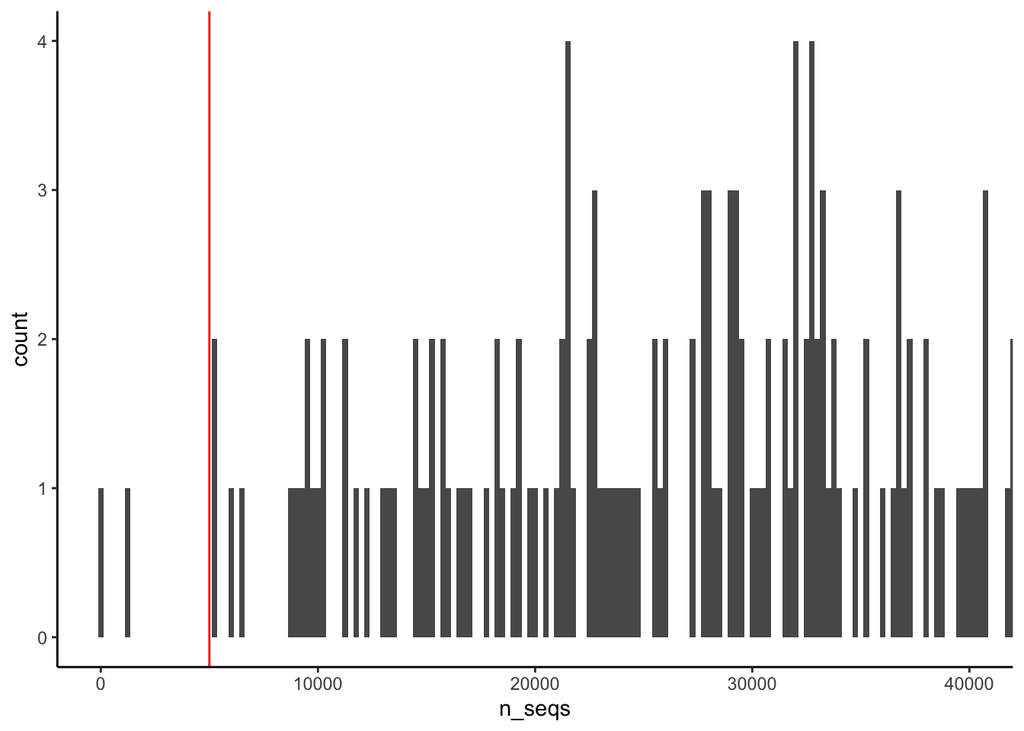

```r
sampling_coverage %>%
  ggplot(aes(x=n_seqs)) +
  geom_histogram(binwidth=250) +
  theme_classic()+
  coord_cartesian(xlim=c(0, 40000))+
  geom_vline(xintercept = c(5000, 5000), col = "red")
```

It can be seen that 2 samples have less than 5000 counts.  
So then I created another curve graph in which the threshold was indicated  
As it was determined from the previous graph, presumably the threshold should be at 5000 counts.  
- The X axis indicates the samples.  
- The Y axis indicates the number of counts.  
It can be seen that two samples in the graph are below 5000 counts.

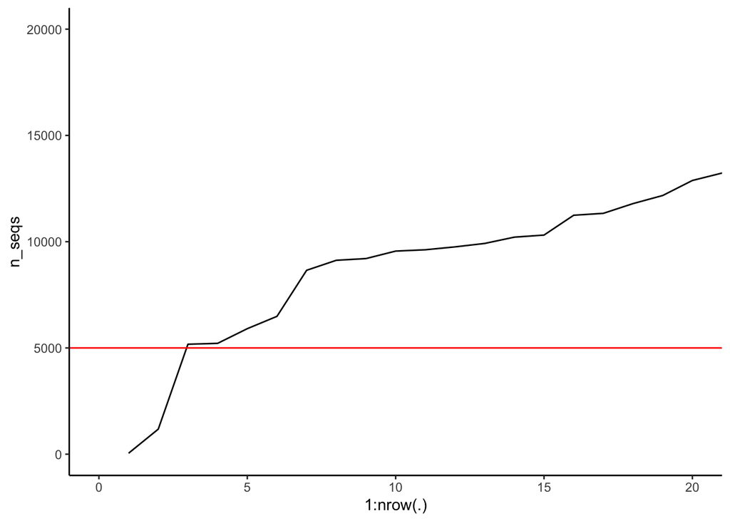

```r
sampling_coverage %>%
  arrange(n_seqs) %>%
  ggplot(aes(x=1:nrow(.), y=n_seqs))+
  geom_line()+
  theme_classic()+
  coord_cartesian(xlim=c(0,20), ylim=c(0, 20000)) +
  geom_hline(yintercept = c(5000, 5000), col = "red")
```

Then I displayed the same data, but in the form of a jitter-plot.  
Now it is clearly seen that 2 samples below the threshold should be removed.

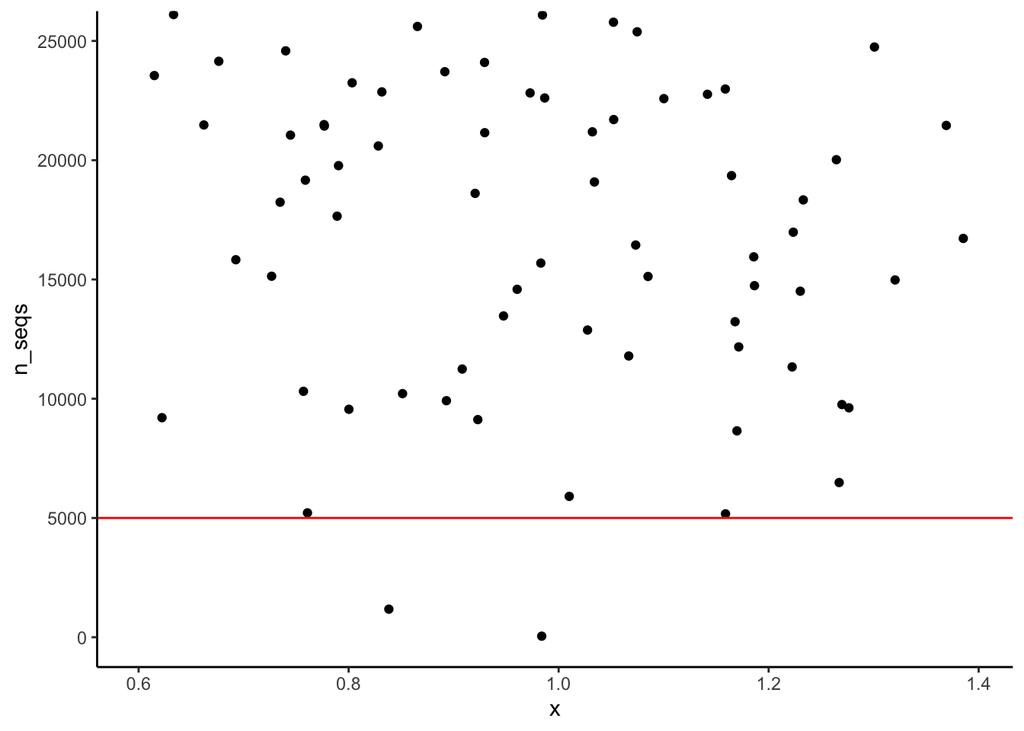

```r
sampling_coverage %>%
  ggplot(aes(x=1, y=n_seqs)) +
  geom_jitter() +
  theme_classic() +
  coord_cartesian(ylim=c(0, 25000))+
  geom_hline(yintercept = c(5000, 5000), col = "red")
```

To identify the samples to be removed from the dataset, I used the following command, which outputed the sample IDs and the number of counts in ascending order:

```r
sampling_coverage %>%
  arrange(n_seqs) %>%
  print(n = 10)
```

```
## # A tibble: 199 × 2
##    sample_id n_seqs
##    <chr>      <int>
##  1 X63A57        45
##  2 X63B47      1178
##  3 X63A66      5174
##  4 X63A79      5215
##  5 X63A51      5906
##  6 X63A68      6486
##  7 X63A77      8654
##  8 X63A91      9124
##  9 X63A88      9205
## 10 X63B59      9557
## # ℹ 189 more rows
```

Now it is seen that:  
Sample `X63A57` has a total of 45 counts.  
Sample `X63B47` has only 1178 counts.  
Thus, I found samples with relatively low counts number that should be removed from the dataset in order to decrease the false positives rate.  
To remove them, I used the following command:

```r
metadata_rarefied <- metadata %>%
  filter(sample_id != "X63A57")%>%
  filter(sample_id != "X63B47")
```

Then I merged taxonomy and counts tables, filtered only genera taxonomy rank (for other taxonomy levels I made the same thing) to get table with counts of identified genera.

```r
otu_rel_abund <- dplyr::inner_join(metadata, OTU_counts, by="sample_id") %>%
  dplyr::inner_join(., taxonomy, by="OTU", multiple = "all") %>%
  group_by(sample_id) %>%
  ungroup() %>%
  pivot_longer(c("Kingdom", "Phylum", "Class", "Order", "Genus", "OTU"),
               names_to="level",
               values_to="taxon")

counts_genus <- otu_rel_abund %>%
  filter(level=="Genus") %>%
  group_by(sample_id, taxon) %>%
  summarise(count = sum(count), .groups = "drop") %>%
  group_by(taxon) %>%
  pivot_wider(names_from = taxon, values_from = count)

head(counts_genus, 10)
```

```
## # A tibble: 10 × 387
##    sample_id `67-14` Abiotrophia Acetanaerobacterium Acetitomaculum
##    <chr>       <int>       <int>               <int>          <int>
##  1 X6261           0           0                   0              0
##  2 X6262           0           0                   0              0
##  3 X6263           0           0                   0              0
##  4 X6264           0           0                   0              0
##  5 X6265           0           0                   0              0
##  6 X6266           0         135                   0              0
##  7 X6267           0           0                   0              0
##  8 X6269           0          13                   0              0
##  9 X6270           0           0                   0              0
## 10 X6271           0           0                   0              0
## # ℹ 382 more variables: Acidaminococcus <int>, Acinetobacter <int>,
## #   Actinobacillus <int>, Actinomyces <int>, Adlercreutzia <int>,
## #   Agathobacter <int>, Aggregatibacter <int>, Akkermansia <int>,
## #   Alistipes <int>, Allisonella <int>, Allobacillus <int>,
## #   Alloprevotella <int>,
## #   `Allorhizobium-Neorhizobium-Pararhizobium-Rhizobium` <int>,
## #   Anaerobiospirillum <int>, Anaerococcus <int>, Anaerofilum <int>, …
```

As I found two samples that are not suitable for the statistical analysis, I removed them from the dataset.

```r
counts_genus_rarefied <- counts_genus %>%
  filter(sample_id != "X63A57")%>%
  filter(sample_id != "X63B47")
```

With this command I changed rownames in the table to the sample IDs, which is required by the Maaslin2 package (which previosly was also made for the metadata).

```r
write.csv(counts_genus_rarefied, "counts_genus_rarefied.csv")

taxon_counts_genus_rarefied <- read.table('counts_genus_rarefied.csv', sep=',',
                                  comment='', head=T, row.names=1)
rownames(taxon_counts_genus_rarefied) <- taxon_counts_genus_rarefied$sample_id
taxon_counts_genus_rarefied <- taxon_counts_genus_rarefied[, -1]
```

```r
taxon_counts_genus_rarefied_include <- colSums(taxon_counts_genus_rarefied>4) > 0.1 * ncol(taxon_counts_genus_rarefied)
taxon_counts_genus_rarefied_filtered <- taxon_counts_genus_rarefied[, taxon_counts_genus_rarefied_include]
```

Then I transformed the counts table to the relative abundances table.  
It is also very important to do so with this type of data (16S rRNA) to decrease false positives rate.  
https://www.frontiersin.org/articles/10.3389/fmicb.2017.02224/full

```r
taxon_genus_abundance = cmultRepl(taxon_counts_genus_rarefied_filtered )
```

```
## No. adjusted imputations:  1386
```

# **Linear modelling for the investigation significant associations between bacterial abundance and clinical features with Maaslin2**

## Making better visualisation

I do not like default heatmap and scatter plots from Maaslin2 output (I find them ugly and not suitable for publication).  
So, I made custom ggplot2-based heatmap.  
For this I uploaded Maaslin2 results and made the genera names in italics (as it should be in civilized microbiology world).  
Default Maaslin2 output represents genera names not in italics format.

```r
DAA_res_genus_sanitation <- read.csv("Sanitation_Genus_rel_abund/significant_results.tsv",
                                     sep = "")%>%
  mutate(feature = str_replace(feature,
                               "Unclassified_(.*)", "Unclassified *\\1*"),
         feature = str_replace(feature,
                               "(.*)_group", "\\1"),
         feature = str_replace(feature,
                               "X.(.*)", "\\1"),
         feature = str_replace(feature,
                               "^(\\S*)$", "*\\1*")) %>%
  mutate(metadata = factor(metadata,
                        levels=c("Toilet",
                                 "Manufacturing_facilities",
                                 "Clean_water_facilities",
                                 "Waste_water_disposal_facility")))
```

With this command I created custom heatmap.  
Heatmap with genera, the relative abundance of which had significant associations with clinical metadata.

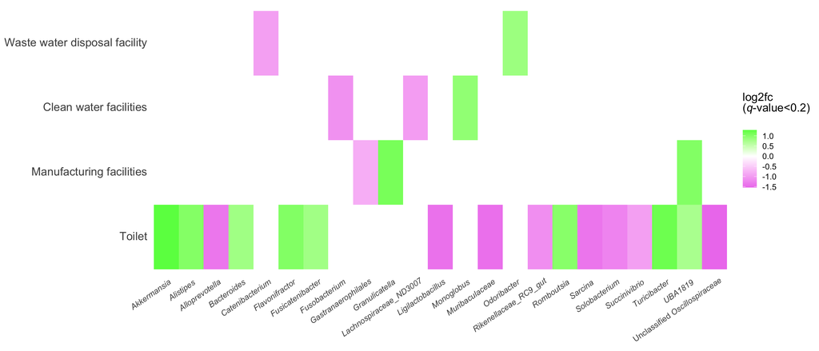

```r
ggplot(data=DAA_res_genus_sanitation, aes(x=feature, fill=coef, y=metadata)) +
  geom_tile()+
  theme_classic()+
  scale_fill_gradient2(name = "log2fc<br>(<i>q</i>-value<0.2)<br>",
                       low = "violet",
                       high = "green",
                       mid = "white",
                       guide = "colourbar")+#,
                       #limits = c(-1.6, 1.6))+
  theme(axis.text.y = element_markdown(size=14),
        axis.text.x = element_markdown(size=10, angle = 35, hjust = 0.95),
        legend.title = element_markdown(size=14),
        axis.line = element_blank(),
        axis.ticks = element_blank(),
        legend.text = element_text(size=10),
        legend.key.height = unit(0.5, 'cm'))+
  scale_y_discrete(breaks=c("Toilet",
                            "Manufacturing_facilities",
                            "Clean_water_facilities",
                            "Waste_water_disposal_facility"),
                   labels=c("Toilet",
                            "Manufacturing facilities",
                            "Clean water facilities",
                            "Waste water disposal facility"))+
  labs(x=NULL,
       y=NULL)
```

And finally, let’s save the heatmap!

```r
ggsave("Heatmaps/genus_sanitation.png", width = 11, height = 3.5, dpi=600)
```

# **References**

The following packages must be installed to work with the dataset:

```r
knitr::write_bib(c("Maaslin2", "tidyverse", "zCompositions", "ggrepel", "ggtext"), file = "packages.bib")
```